# Sprawozdanie 2

Andrzej Miczek, Jakub Laszczyk

2023-10-13

## **Wstęp teoretyczny**

Do wykonania Zadania 2 dotyczącego braków danych wybraliśmy trzy metody:

**1. Usunięcie braków**

Eliminacja braków w danych poprzez usunięcie obserwacji to jedna z technik zarządzania brakującymi danymi w analizie danych. Jest to proces usuwania rekordów lub obserwacji, które zawierają brakujące wartości lub wartości odstające, z danych wejściowych. Metoda ta może być przydatna, gdy brakujące dane są nieliczne lub nieodzowne, ale należy ją stosować ostrożnie, aby nie wprowadzić zniekształceń ani nie utracić ważnych informacji, które mogły mieć ważny wpływ na końcowy rezultat badań.

**2. Zastąpienie braków średnią/medianą lub najczęsciej występującą obserwacją w zależności od typu zmiennych**

Eliminacja braków w danych poprzez zastępowanie ich średnią, medianą lub najczęściej występującą obserwacją jest jedną z technik imputacji danych brakujących. Ta technika polega na zastępowaniu brakujących wartości w zmiennych danych pewnymi stałymi wartościami statystycznymi, które są charakterystyczne dla danego zestawu danych. Wybór miary tendencji centralnej (średniej, mediany lub najczęściej występującej wartości) zależy od typu zmiennej, jaką się analizuje.

**Dla zmiennych numerycznych ciągłych** (np. wiek, dochód) najczęściej używa się średniej arytmetycznej (średniej), ponieważ jest to miara tendencji centralnej, która uwzględnia wszystkie dostępne wartości. Średnia obliczana jest poprzez sumowanie wszystkich dostępnych obserwacji i dzielenie przez liczbę tych obserwacji.

**Dla zmiennych numerycznych dyskretnych lub o rozkładzie skośnym**, można zastosować medianę. Mediana to wartość, która dzieli dane na dwie równe części, czyli 50% obserwacji jest poniżej mediany, a 50% powyżej. Jest mniej podatna na wpływ wartości odstających niż średnia.

**Dla zmiennych kategorialnych (np. płeć)** można zastąpić brakujące dane najczęściej występującą kategorią (wartością modalną), ponieważ nie ma sensu obliczać średniej ani mediany dla zmiennych jakościowych.

**3. Zastąpienie braków przy wykorzystaniu knn**

Eliminacja braków w danych przy wykorzystaniu Machine Learning, a konkretnie algorytmu K-Nearest Neighbors (KNN), to zaawansowana metoda imputacji danych brakujących. KNN jest algorytmem uczenia nadzorowanego, który może być wykorzystany do przewidywania brakujących wartości w oparciu o podobieństwo między obserwacjami. Metoda ta jest bardziej zaawansowaną techniką niż zastępowanie braków średnią, medianą lub modalną, ponieważ uwzględnia wzajemne zależności między obserwacjami. Jednak może być bardziej czasochłonna i wymaga uważnego doboru hiperparametrów. Wyniki zależą od jakości dostępnych danych i wyboru odpowiedniego K.

## **Wczytanie danych**

```r
library(VIM)
library(caret)
library(psych)
dane_S<-read.csv("zad2_Stroke.csv", sep = ";")
dane_A<-read.csv("zad2_Airline.csv", sep = ";")
dane_H<-read.csv("zad2_Heart.csv", sep = ";")
```

## **Przygotowanie zbioru danych**

```r
str(dane_S)
```

```
## 'data.frame':    400 obs. of  11 variables:
##  $ gender           : chr  "Male" "Male" "Female" "Female" ...
##  $ age              : chr  "67" "80" "49" "79" ...
##  $ hypertension     : int  0 0 0 1 0 1 0 0 0 0 ...
##  $ heart_disease    : int  1 1 0 NA 0 1 0 0 0 1 ...
##  $ ever_married     : chr  "Yes" "Yes" "Yes" "Yes" ...
##  $ work_type        : chr  "Private" "Private" "Private" "Self-employed" ...
##  $ Residence_type   : chr  "Urban" "Rural" "Urban" "Rural" ...
##  $ avg_glucose_level: chr  "228,69" "105,92" "171,23" "174,12" ...
##  $ bmi              : chr  "36,6" "32,5" "34,4" "24" ...
##  $ smoking_status   : chr  "formerly smoked" "never smoked" "smokes" "never smoked" ...
##  $ stroke           : int  1 1 1 1 1 1 1 1 1 1 ...
```

```r
dane_S[,2]<-as.numeric(gsub(",", ".", gsub("\\.", "", dane_S[,2])))
dane_S[,8]<-as.numeric(gsub(",", ".", gsub("\\.", "", dane_S[,8])))
dane_S[,9]<-as.numeric(gsub(",", ".", gsub("\\.", "", dane_S[,9])))

str(dane_H)
```

```
## 'data.frame':    818 obs. of  12 variables:
##  $ Age           : int  40 49 37 48 54 39 45 54 48 37 ...
##  $ Sex           : chr  "M" "F" "M" "F" ...
##  $ ChestPainType : chr  "ATA" "NAP" "ATA" "ASY" ...
##  $ RestingBP     : int  140 160 130 138 150 120 130 110 120 130 ...
##  $ Cholesterol   : int  289 180 283 214 195 339 237 208 284 211 ...
##  $ FastingBS     : int  0 0 0 0 0 0 0 0 0 0 ...
##  $ RestingECG    : chr  "Normal" "Normal" "ST" "Normal" ...
##  $ MaxHR         : int  172 156 98 108 122 170 170 142 120 142 ...
##  $ ExerciseAngina: chr  "N" "N" "N" "Y" ...
##  $ Oldpeak       : chr  "0" "1" "0" "1,5" ...
##  $ ST_Slope      : chr  "Up" "Flat" "Up" "Flat" ...
##  $ HeartDisease  : int  0 1 0 1 0 0 0 0 0 0 ...
```

```r
dane_H[,10]<-as.numeric(gsub(",", ".", gsub("\\.", "", dane_H[,10])))
```

```r
braki_w_kolumnachS <- colSums(is.na(dane_S))
braki_w_kolumnachH <- colSums(is.na(dane_H))
braki_w_kolumnachA <- colSums(is.na(dane_A))
braki_w_kolumnachS
```

```
##            gender               age      hypertension     heart_disease
##                 0                 0                 0                24
##      ever_married         work_type    Residence_type avg_glucose_level
##                 0                47                 0                41
##               bmi    smoking_status            stroke
##                37                 0                 0
```

```r
braki_w_kolumnachH
```

```
##            Age            Sex  ChestPainType      RestingBP    Cholesterol
##             47              0              0              0             55
##      FastingBS     RestingECG          MaxHR ExerciseAngina        Oldpeak
##              0             37              0             31             28
##       ST_Slope   HeartDisease
##              0              0
```

```r
braki_w_kolumnachA
```

```
##                      satisfaction                            Gender
##                                 0                                 0
##                     Customer.Type                               Age
##                               210                                86
##                    Type.of.Travel                             Class
##                                 0                                 0
##                   Flight.Distance                      Seat.comfort
##                                 0                                 0
## Departure.Arrival.time.convenient                    Food.and.drink
##                                 0                                 0
##                     Gate.location             Inflight.wifi.service
##                               100                                 0
##            Inflight.entertainment                    Online.support
##                                 0                                 0
##            Ease.of.Online.booking                  On.board.service
##                                 0                                 0
##                  Leg.room.service                  Baggage.handling
##                                 0                                 0
##                   Checkin.service                       Cleanliness
##                                 0                                 0
##                   Online.boarding        Departure.Delay.in.Minutes
##                                 0                                 0
##          Arrival.Delay.in.Minutes
##                                15
```

## **Metoda I**

**Usunięcie braków**

```r
dane_S1<-na.omit(dane_S)
dane_A1<-na.omit(dane_A)
dane_H1<-na.omit(dane_H)
```

**Budowa modelu**

**Zbiór Stroke**

```r
dummy_data <- dummyVars(~ work_type, data = dane_S1)
dummy_data_transformed <- as.data.frame(predict(dummy_data, newdata = dane_S1))
dane_S1 <- cbind(dane_S1, dummy_data_transformed)

dummy_data <- dummyVars(~ Residence_type, data = dane_S1)
dummy_data_transformed <- as.data.frame(predict(dummy_data, newdata = dane_S1))
dane_S1 <- cbind(dane_S1, dummy_data_transformed)

dummy_data <- dummyVars(~ smoking_status, data = dane_S1)
dummy_data_transformed <- as.data.frame(predict(dummy_data, newdata = dane_S1))
dane_S1 <- cbind(dane_S1, dummy_data_transformed)

dane_S1$gender <- ifelse(dane_S1$gender == "Male", 1, 0)
dane_S1$ever_married <- ifelse(dane_S1$ever_married == "Yes", 1, 0)
dane_S1$Stroke <- dane_S1$stroke
dane_S1 <- dane_S1[,-c(6,7,10,11,16,17)]
str(dane_S1$age)
```

```
##  num [1:268] 67 80 49 81 74 78 61 54 64 75 ...
```

```r
dane_S1$Stroke <- as.factor(dane_S1$Stroke)
# Podzial na zbior uczacy i testowy dla zbioru
set.seed(123)
ind <- sample(2, nrow(dane_S1), replace = TRUE, prob = c(0.7, 0.3))
train_set1 <- dane_S1[ind==1,]
test_set1  <- dane_S1[ind==2,]

# Regresja logistyczna
formula <- Stroke~.
model <- glm(formula , data = train_set1, family = binomial)

# Predykcja na zbiorze testowym
predictions <- predict(model, test_set1, type = 'response')
# Zamiana prawdopodobienstwa na 0 i 1
predicted_classes <- ifelse(predictions >= 0.5, 1,0)
predicted_classes <- as.factor(predicted_classes)
confusionMatrix(predicted_classes, test_set1$Stroke)
```

```
## Confusion Matrix and Statistics
##
##           Reference
## Prediction  0  1
##          0 32  9
##          1  6 27
##
##                Accuracy : 0.7973
##                  95% CI : (0.6878, 0.8819)
##     No Information Rate : 0.5135
##     P-Value [Acc > NIR] : 4.154e-07
##
##                   Kappa : 0.5934
##
##  Mcnemar's Test P-Value : 0.6056
##
##             Sensitivity : 0.8421
##             Specificity : 0.7500
##          Pos Pred Value : 0.7805
##          Neg Pred Value : 0.8182
##              Prevalence : 0.5135
##          Detection Rate : 0.4324
##    Detection Prevalence : 0.5541
##       Balanced Accuracy : 0.7961
##
##        'Positive' Class : 0
##
```

**Zbiór Heart**

```r
str(dane_H1)
```

```
## 'data.frame':    636 obs. of  12 variables:
##  $ Age           : int  40 49 37 48 54 39 45 54 48 37 ...
##  $ Sex           : chr  "M" "F" "M" "F" ...
##  $ ChestPainType : chr  "ATA" "NAP" "ATA" "ASY" ...
##  $ RestingBP     : int  140 160 130 138 150 120 130 110 120 130 ...
##  $ Cholesterol   : int  289 180 283 214 195 339 237 208 284 211 ...
##  $ FastingBS     : int  0 0 0 0 0 0 0 0 0 0 ...
##  $ RestingECG    : chr  "Normal" "Normal" "ST" "Normal" ...
##  $ MaxHR         : int  172 156 98 108 122 170 170 142 120 142 ...
##  $ ExerciseAngina: chr  "N" "N" "N" "Y" ...
##  $ Oldpeak       : num  0 1 0 1.5 0 0 0 0 0 0 ...
##  $ ST_Slope      : chr  "Up" "Flat" "Up" "Flat" ...
##  $ HeartDisease  : int  0 1 0 1 0 0 0 0 0 0 ...
##  - attr(*, "na.action")= 'omit' Named int [1:182] 12 22 24 29 32 36 42 49 51 60 ...
##   ..- attr(*, "names")= chr [1:182] "12" "22" "24" "29" ...
```

```r
dane_H1$Sex <- ifelse(dane_H1$Sex == "M", 1, 0)
dane_H1$ExerciseAngina <- ifelse(dane_H1$ExerciseAngina == "N",1,0)
dane_H1$Oldpeak <- as.numeric(gsub(",", ".", gsub("\\.", "", dane_H1$Oldpeak)))
dane_H1$HeartDisease <- as.factor(dane_H1$HeartDisease)


dummy_data <- dummyVars(~ ChestPainType, data = dane_H1)
dummy_data_transformed <- as.data.frame(predict(dummy_data, newdata = dane_H1))
dane_H1 <- cbind(dane_H1, dummy_data_transformed)

dummy_data <- dummyVars(~ RestingECG, data = dane_H1)
dummy_data_transformed <- as.data.frame(predict(dummy_data, newdata = dane_H1))
dane_H1 <- cbind(dane_H1, dummy_data_transformed)

dummy_data <- dummyVars(~ ST_Slope, data = dane_H1)
dummy_data_transformed <- as.data.frame(predict(dummy_data, newdata = dane_H1))
dane_H1 <- cbind(dane_H1, dummy_data_transformed)

dane_H1$heartDisease <- dane_H1$HeartDisease
dane_H1 <- dane_H1[,-c(3,7,11,12,16,19,22)]
str(dane_H1)
```

```
## 'data.frame':    636 obs. of  16 variables:
##  $ Age             : int  40 49 37 48 54 39 45 54 48 37 ...
##  $ Sex             : num  1 0 1 0 1 1 0 1 0 0 ...
##  $ RestingBP       : int  140 160 130 138 150 120 130 110 120 130 ...
##  $ Cholesterol     : int  289 180 283 214 195 339 237 208 284 211 ...
##  $ FastingBS       : int  0 0 0 0 0 0 0 0 0 0 ...
##  $ MaxHR           : int  172 156 98 108 122 170 170 142 120 142 ...
##  $ ExerciseAngina  : num  1 1 1 0 1 1 1 1 1 1 ...
##  $ Oldpeak         : num  0 1 0 15 0 0 0 0 0 0 ...
##  $ ChestPainTypeASY: num  0 0 0 1 0 0 0 0 0 0 ...
##  $ ChestPainTypeATA: num  1 0 1 0 0 0 1 1 1 0 ...
##  $ ChestPainTypeNAP: num  0 1 0 0 1 1 0 0 0 1 ...
##  $ RestingECGLVH   : num  0 0 0 0 0 0 0 0 0 0 ...
##  $ RestingECGNormal: num  1 1 0 1 1 1 1 1 1 1 ...
##  $ ST_SlopeDown    : num  0 0 0 0 0 0 0 0 0 0 ...
##  $ ST_SlopeFlat    : num  0 1 0 1 0 0 0 0 0 0 ...
##  $ heartDisease    : Factor w/ 2 levels "0","1": 1 2 1 2 1 1 1 1 1 1 ...
```

```r
# Podzial na zbior uczacy i testowy heart
set.seed(123)
ind <- sample(2, nrow(dane_H1), replace = TRUE, prob = c(0.7, 0.3))
train_set2 <- dane_H1[ind==1,]
test_set2  <- dane_H1[ind==2,]

# Model
formula <- heartDisease~.
model <- glm(formula , data = train_set2, family = binomial)

# Predykcja na zbiorze testowym
predictions <- predict(model, test_set2, type = 'response')

#Zamiana prawdopodobienstwa na 0 i 1
predicted_classes <- ifelse(predictions >= 0.5, 1,0)
predicted_classes <- as.factor(predicted_classes)
confusionMatrix(predicted_classes, test_set2$heartDisease)
```

```
## Confusion Matrix and Statistics
##
##           Reference
## Prediction  0  1
##          0 84 10
##          1 18 78
##
##                Accuracy : 0.8526
##                  95% CI : (0.7941, 0.8998)
##     No Information Rate : 0.5368
##     P-Value [Acc > NIR] : <2e-16
##
##                   Kappa : 0.7055
##
##  Mcnemar's Test P-Value : 0.1859
##
##             Sensitivity : 0.8235
##             Specificity : 0.8864
##          Pos Pred Value : 0.8936
##          Neg Pred Value : 0.8125
##              Prevalence : 0.5368
##          Detection Rate : 0.4421
##    Detection Prevalence : 0.4947
##       Balanced Accuracy : 0.8549
##
##        'Positive' Class : 0
##
```

**Zbiór Airline**

```r
str(dane_A1)
```

```
## 'data.frame':    3597 obs. of  23 variables:
##  $ satisfaction                     : chr  "satisfied" "satisfied" "satisfied" "satisfied" ...
##  $ Gender                           : chr  "Female" "Female" "Male" "Male" ...
##  $ Customer.Type                    : chr  "Loyal Customer" "Loyal Customer" "Loyal Customer" "Loyal Customer" ...
##  $ Age                              : int  20 48 13 34 48 12 37 7 46 41 ...
##  $ Type.of.Travel                   : chr  "Personal Travel" "Personal Travel" "Personal Travel" "Personal Travel" ...
##  $ Class                            : chr  "Eco" "Eco" "Eco" "Eco" ...
##  $ Flight.Distance                  : int  3009 1449 2306 1952 457 2794 1303 1474 1060 3657 ...
##  $ Seat.comfort                     : int  0 0 0 0 0 0 0 0 0 0 ...
##  $ Departure.Arrival.time.convenient: int  1 1 1 1 2 3 4 4 4 4 ...
##  $ Food.and.drink                   : int  0 0 0 0 0 0 0 0 0 0 ...
##  $ Gate.location                    : int  3 3 3 3 4 1 1 3 3 4 ...
##  $ Inflight.wifi.service            : int  4 3 4 2 5 3 5 3 1 2 ...
##  $ Inflight.entertainment           : int  0 3 0 0 4 0 0 0 0 0 ...
##  $ Online.support                   : int  3 2 3 2 4 3 5 3 1 2 ...
##  $ Ease.of.Online.booking           : int  4 2 4 2 4 3 5 3 1 2 ...
##  $ On.board.service                 : int  1 2 4 3 4 3 4 4 4 1 ...
##  $ Leg.room.service                 : int  2 1 2 4 0 2 2 2 1 2 ...
##  $ Baggage.handling                 : int  3 2 3 4 4 4 4 5 4 3 ...
##  $ Checkin.service                  : int  1 4 2 4 4 2 3 3 3 4 ...
##  $ Cleanliness                      : int  4 2 2 4 4 2 2 5 4 4 ...
##  $ Online.boarding                  : int  4 2 4 2 3 3 5 3 1 2 ...
##  $ Departure.Delay.in.Minutes       : int  0 0 0 10 0 14 0 0 2 0 ...
##  $ Arrival.Delay.in.Minutes         : int  0 2 0 0 0 1 0 0 4 0 ...
##  - attr(*, "na.action")= 'omit' Named int [1:403] 3 6 7 20 21 40 41 42 46 52 ...
##   ..- attr(*, "names")= chr [1:403] "3" "6" "7" "20" ...
```

```r
dane_A1$satisfaction <- as.factor(dane_A1$satisfaction)
dane_A1$satisfaction <- as.integer(dane_A1$satisfaction)-1
dane_A1$satisfaction <- as.factor(dane_A1$satisfaction)

dane_A1$Gender <- ifelse(dane_A1$Gender == "Male",1,0)
dane_A1$Customer.Type <- ifelse(dane_A1$Customer.Type == "Loyal Customer",1,0)
dane_A1$Type.of.Travel <- ifelse(dane_A1$Type.of.Travel == "Personal Travel",1,0)

dummy_data <- dummyVars(~ Class, data = dane_A1)
dummy_data_transformed <- as.data.frame(predict(dummy_data, newdata = dane_A1))
dane_A1 <- cbind(dane_A1, dummy_data_transformed)

dane_A1$Satisfaction <- dane_A1$satisfaction
dane_A1 <- dane_A1[,-c(1,6,26)]
str(dane_A1)
```

```
## 'data.frame':    3597 obs. of  24 variables:
##  $ Gender                           : num  0 0 1 1 0 1 1 0 1 0 ...
##  $ Customer.Type                    : num  1 1 1 1 1 1 1 1 1 1 ...
##  $ Age                              : int  20 48 13 34 48 12 37 7 46 41 ...
##  $ Type.of.Travel                   : num  1 1 1 1 1 1 1 1 1 1 ...
##  $ Flight.Distance                  : int  3009 1449 2306 1952 457 2794 1303 1474 1060 3657 ...
##  $ Seat.comfort                     : int  0 0 0 0 0 0 0 0 0 0 ...
##  $ Departure.Arrival.time.convenient: int  1 1 1 1 2 3 4 4 4 4 ...
##  $ Food.and.drink                   : int  0 0 0 0 0 0 0 0 0 0 ...
##  $ Gate.location                    : int  3 3 3 3 4 1 1 3 3 4 ...
##  $ Inflight.wifi.service            : int  4 3 4 2 5 3 5 3 1 2 ...
##  $ Inflight.entertainment           : int  0 3 0 0 4 0 0 0 0 0 ...
##  $ Online.support                   : int  3 2 3 2 4 3 5 3 1 2 ...
##  $ Ease.of.Online.booking           : int  4 2 4 2 4 3 5 3 1 2 ...
##  $ On.board.service                 : int  1 2 4 3 4 3 4 4 4 1 ...
##  $ Leg.room.service                 : int  2 1 2 4 0 2 2 2 1 2 ...
##  $ Baggage.handling                 : int  3 2 3 4 4 4 4 5 4 3 ...
##  $ Checkin.service                  : int  1 4 2 4 4 2 3 3 3 4 ...
##  $ Cleanliness                      : int  4 2 2 4 4 2 2 5 4 4 ...
##  $ Online.boarding                  : int  4 2 4 2 3 3 5 3 1 2 ...
##  $ Departure.Delay.in.Minutes       : int  0 0 0 10 0 14 0 0 2 0 ...
##  $ Arrival.Delay.in.Minutes         : int  0 2 0 0 0 1 0 0 4 0 ...
##  $ ClassBusiness                    : num  0 0 0 0 0 0 0 0 0 0 ...
##  $ ClassEco                         : num  1 1 1 1 1 1 1 1 0 1 ...
##  $ Satisfaction                     : Factor w/ 2 levels "0","1": 2 2 2 2 2 2 2 2 2 2 ...
```

```r
# Podzial na zbior uczacy i testowy heart
set.seed(123)
ind <- sample(2, nrow(dane_A1), replace = TRUE, prob = c(0.7, 0.3))
train_set3 <- dane_A1[ind==1,]
test_set3  <- dane_A1[ind==2,]

# Model
formula <- Satisfaction~.
model <- glm(formula , data = train_set3, family = binomial)

# Predykcja na zbiorze testowym
predictions <- predict(model, test_set3, type = 'response')

# Zamiana prawdopodobienstwa na 0 i 1
predicted_classes <- ifelse(predictions >= 0.5, 1,0)
predicted_classes <- as.factor(predicted_classes)
confusionMatrix(predicted_classes, test_set3$Satisfaction)
```

```
## Confusion Matrix and Statistics
##
##           Reference
## Prediction   0   1
##          0 441  98
##          1  74 464
##
##                Accuracy : 0.8403
##                  95% CI : (0.817, 0.8617)
##     No Information Rate : 0.5218
##     P-Value [Acc > NIR] : < 2e-16
##
##                   Kappa : 0.6806
##
##  Mcnemar's Test P-Value : 0.07948
##
##             Sensitivity : 0.8563
##             Specificity : 0.8256
##          Pos Pred Value : 0.8182
##          Neg Pred Value : 0.8625
##              Prevalence : 0.4782
##          Detection Rate : 0.4095
##    Detection Prevalence : 0.5005
##       Balanced Accuracy : 0.8410
##
##        'Positive' Class : 0
##
```

## **Metoda II**

**Sprawdzenie wartości odstających**

```r
dane_S3<-na.omit(dane_S)
dane_A3<-na.omit(dane_A)
dane_H3<-na.omit(dane_H)
# Funkcja do wykrywania wartosci odstających na podstawie odchylenia standardowego
detect_outliers_std <- function(series, n_std = 3) {
  mean_val <- mean(series)
  std_val <- sd(series)
  lower_bound <- mean_val - n_std * std_val
  upper_bound <- mean_val + n_std * std_val
  outliers <- (series < lower_bound) | (series > upper_bound)
  return(data.frame(Liczba_Obserwacji = sum(outliers), Dolna_Granica = lower_bound, Gorna_Granica = upper_bound))
}


# Obliczenie wartosci odstajacych dla kazdego zbioru danych
# Funkcje do wykrywania wartosci odstających dla kazdej kolumny
outliers_std <- lapply(dane_A3, detect_outliers_std)
# Tworzenie ramki danych
outliers_std_df <- do.call(rbind, outliers_std)
outliers_std_df$Nazwa_Zmiennej <- rownames(outliers_std_df)
rownames(outliers_std_df) <- NULL
# Wyswietlenie wynikowych ramek danych
print("\nOutliers Standard Deviation:")
```

```
## [1] "\nOutliers Standard Deviation:"
```

```r
print(outliers_std_df)
```

```
##    Liczba_Obserwacji Dolna_Granica Gorna_Granica
## 1                 NA            NA            NA
## 2                 NA            NA            NA
## 3                 NA            NA            NA
## 4                  1    -6.0369223     84.741398
## 5                 NA            NA            NA
## 6                 NA            NA            NA
## 7                 29 -1204.2717168   5148.173301
## 8                  0    -1.3321956      6.863472
## 9                  0    -1.5927026      7.597707
## 10                 0    -1.4720384      7.172344
## 11                 0    -0.9337144      6.905357
## 12                 0    -0.8380674      7.223388
## 13                 0    -0.7401213      7.376207
## 14                 0    -0.4697411      7.419421
```

[output cut: 33 more lines]

```r
# Funkcje do wykrywania wartosci odstających dla kazdej kolumny
outliers_std <- lapply(dane_H3, detect_outliers_std)
# Tworzenie ramki danych dla obu metod
outliers_std_df <- do.call(rbind, outliers_std)
outliers_std_df$Nazwa_Zmiennej <- rownames(outliers_std_df)
rownames(outliers_std_df) <- NULL
# Wyswietlenie wynikowych ramek danych
print("\nOutliers Standard Deviation:")
```

```
## [1] "\nOutliers Standard Deviation:"
```

```r
print(outliers_std_df)
```

```
##    Liczba_Obserwacji Dolna_Granica Gorna_Granica Nazwa_Zmiennej
## 1                  0     25.190136     81.835022            Age
## 2                 NA            NA            NA            Sex
## 3                 NA            NA            NA  ChestPainType
## 4                  5     74.937210    190.220022      RestingBP
## 5                  1   -122.538729    521.545018    Cholesterol
## 6                  0     -1.025450      1.468846      FastingBS
## 7                 NA            NA            NA     RestingECG
## 8                  0     61.560423    215.351526          MaxHR
## 9                 NA            NA            NA ExerciseAngina
## 10                 6     -2.417887      4.093044        Oldpeak
## 11                NA            NA            NA       ST_Slope
## 12                 0     -1.016161      1.984715   HeartDisease
```

```r
# Funkcje do wykrywania wartosci odstających dla kazdej kolumny
outliers_std <- lapply(dane_S3, detect_outliers_std)
# Tworzenie ramki danych dla obu metod
outliers_std_df <- do.call(rbind, outliers_std)
outliers_std_df$Nazwa_Zmiennej <- rownames(outliers_std_df)

rownames(outliers_std_df) <- NULL
# Wyswietlenie wynikowych ramek danych
print("\nOutliers Standard Deviation:")
```

```
## [1] "\nOutliers Standard Deviation:"
```

```r
print(outliers_std_df)
```

```
##    Liczba_Obserwacji Dolna_Granica Gorna_Granica    Nazwa_Zmiennej
## 1                 NA            NA            NA            gender
## 2                  0   -14.7149548    121.709582               age
## 3                  0    -1.0041040      1.407089      hypertension
## 4                  0    -0.8987644      1.174884     heart_disease
## 5                 NA            NA            NA      ever_married
## 6                 NA            NA            NA         work_type
## 7                 NA            NA            NA    Residence_type
## 8                  0   -43.0468440    287.896471 avg_glucose_level
## 9                  4     6.2485918     54.900662               bmi
## 10                NA            NA            NA    smoking_status
## 11                 0    -1.0442250      1.947210            stroke
```

**Zastąpienie średnią/medianą lub najczęsciej występującą obserwacją w zależności od typu zmiennych**

Na podstawie wyników z sprawdzenia wartości odstających i typów zmiennych zostały zastosowane odpowiednie sposoby elimnacji błędóW. (np. występowanie wartości odstających dla zmiennych numerycznych - zastosowanie mediany)

**Zbiór Airline**

```r
sum(is.na(dane_A$Customer.Type))
```

```
## [1] 210
```

```r
unique(dane_A$Customer.Type)
```

```
## [1] "Loyal Customer"    NA                  "disloyal Customer"
```

```r
table(dane_A$Customer.Type)
```

```
##
## disloyal Customer    Loyal Customer
##               708              3082
```

```r
dane_A$Customer.Type[is.na(dane_A$Customer.Type)] <- sample (c('Loyal Customer','disloyal Customer'), prob=c(.80,.20))

sum(is.na(dane_A[,4]))
```

```
## [1] 86
```

```r
dane_A$Age[is.na(dane_A[,4])]<-round(mean(dane_A[,4],na.rm=TRUE),0)
unique(dane_A[,4])
```

```
##  [1] 20 48 39 13 34 70 59 12 37  7 46 41 14 19 21 52 35 53 28 60 68 57 11 56  9
## [26] 65 16 47 31 51 22 32 25 54 42 45 36 29 61 50 23 67 43 24 62  8 27 44 18 15
## [51] 49 63 17 69 66 33 38 58 30 26 55 64 10 40 72 80 79 71 78 77 74 76 85 75 73
```

```r
#table(dane_A[,4])

sum(is.na(dane_A[,11]))
```

```
## [1] 100
```

```r
unique(dane_A[,11])
```

```
## [1]  3  4  1 NA  2  5
```

```r
#table(dane_A[,11])
dane_A$Gate.location[is.na(dane_A[,11])]<-3
sum(is.na(dane_A[,11]))
```

```
## [1] 0
```

```r
sum(is.na(dane_A[,23]))
```

```
## [1] 15
```

```r
median(dane_A1[,23])
```

```
## [1] 0
```

```r
unique(dane_A[,23])
```

```
##   [1]   0   2  45   1   4  17   6   3  11  33  37  56   5  15   9  76  12  23
##  [19] 195  NA  41  62  13  35  61   7 123 127  20   8  67  21  78  28 175  14
##  [37]  99  34 152  31 101  19  10  18  29  48 112 157  49  30  87 119  25  36
##  [55]  39  44  27 132  42  43  32  22  47  53 169 291 702  59  79  65  51  77
##  [73]  73  50 161  72  16  52  68  91 110 118  92  69  24  60 232  57  85 138
##  [91]  95  96 103  58 182  54 135 102 105 218 142  93  66 381  83 418 164  55
## [109]  75  26 121 279  46  38 165 143  71 148 129  89 399 130  80 113  74  81
## [127] 116 401 184 283 205 122  82  63  64  70 215 210 117 377 272 100 146  84
## [145] 125 287 163 108 167 144  94 156  90 273 200 109 329 187 139 106  88 198
## [163] 209 174 168 104 107 245 133 203  40  98 310 166 176  97 170 124 115 204
## [181] 281 186 334 128 208 247 221  86 190 114 251 231 323 262 145 729 196
```

```r
#table(dane_A[,23])
dane_A$Arrival.Delay.in.Minutes[is.na(dane_A[,23])]<-median(dane_A1[,23])
sum(is.na(dane_A[,23]))
```

```
## [1] 0
```

```r
sum(is.na(dane_A))
```

```
## [1] 0
```

**Zbiór Heart**

```r
sum(is.na(dane_H[,1]))
```

```
## [1] 47
```

```r
unique(dane_H[,1])
```

```
##  [1] 40 49 37 48 54 39 45 58 42 38 43 60 36 44 53 52 51 56 41 32 NA 35 59 50 31
## [26] 46 57 55 63 65 34 47 61 62 28 30 29 33 74 68 72 64 69 67 66 73 70 77 75 76
## [51] 71
```

```r
#table(dane_H[,1])
dane_H$Age[is.na(dane_H[,1])]<-round(mean(dane_H[,1],na.rm=TRUE),0)
sum(is.na(dane_H[,1]))
```

```
## [1] 0
```

```r
sum(is.na(dane_H[,5]))
```

```
## [1] 55
```

```r
unique(dane_H[,5])
```

```
##   [1] 289 180 283 214 195 339 237 208 284 211 164 204 234 273 196 201 248 267
##  [19] 223 184 288 215 209 260 468  NA 518 167 172 186 254 306 250 177 227 230
##  [37] 264 259 318 216 340 233 205 224 194 270 213 365 253 277 202 297 225 246
##  [55] 412 182 218 163 100 206 238 263 291 229 307 210 329 207 147  85 269 275
##  [73] 179 466 129 241 188 255 272 393 161 228 292 388 294 265 166 247 341 243
##  [91] 279 198 249 168 159 342 190 185 290 212 231 222 235 187 287 404 312 251
## [109] 328 280 245 192 193 268 219 308 132 276 226 217 303 298 256 295 315 281
## [127] 309 200 336 355 326 266 171 491 271 274 160 320 221 126 305 220 242 347
## [145] 344 358 169 181   0 236 203 240 153 316 311 252 458 384 282 349 258 197
## [163] 113 175 310 110 123 170 173 285 165 300 385 322 564 261 239 293 149 199
## [181] 417 178 319 354 244 302 313 141 327 304 286 360 232 262 325 299 409 394
## [199] 174 330 183 257 321 353 335 278 157 176 131
```

```r
#table(dane_H[,5])
dane_H$Cholesterol[is.na(dane_H[,5])]<-median(dane_H1[,5])
sum(is.na(dane_H[,5]))
```

```
## [1] 0
```

```r
sum(is.na(dane_H[,7]))
```

```
## [1] 37
```

```r
unique(dane_H[,7])
```

```
## [1] "Normal" "ST"     NA       "LVH"
```

```r
#table(dane_H[,7])
dane_H$RestingECG[is.na(dane_H[,7])]<-"Normal"
sum(is.na(dane_H[,7]))
```

```
## [1] 0
```

```r
sum(is.na(dane_H[,9]))
```

```
## [1] 31
```

```r
unique(dane_H[,9])
```

```
## [1] "N" "Y" NA
```

```r
#table(dane_H[,9])
dane_H$ExerciseAngina[is.na(dane_H$ExerciseAngina)] <- sample (c('N','Y'), prob=c(.6,.4))
sum(is.na(dane_H[,9]))
```

```
## [1] 0
```

```r
sum(is.na(dane_H[,10]))
```

```
## [1] 28
```

```r
unique(dane_H[,10])
```

```
##  [1]  0.0  1.0  1.5  2.0  3.0  4.0   NA  0.5  2.5  5.0  0.8  0.7  1.4  2.1  0.4
## [16]  0.2  1.7  2.2  0.1  1.3  0.3  1.8  2.6  2.8 -2.6 -1.5 -0.1  0.9  1.1 -1.1
## [31] -0.7 -0.8  1.6  3.7 -1.0  1.2 -2.0 -0.5  1.9  3.5  2.4  0.6  3.1  2.3  3.4
## [46]  3.6  4.2  3.2  5.6  3.8  2.9  6.2
```

```r
#table(dane_H[,10])
dane_H$Oldpeak[is.na(dane_H[,10])]<-median(dane_H1[,10])
sum(is.na(dane_H[,10]))
```

```
## [1] 0
```

```r
sum(is.na(dane_H))
```

```
## [1] 0
```

**Zbiór Stroke**

```r
sum(is.na(dane_S[,4]))
```

```
## [1] 24
```

```r
unique(dane_S[,4])
```

```
## [1]  1  0 NA
```

```r
#table(dane_S[,4])
dane_S$heart_disease[is.na(dane_S[,4])]<-0
sum(is.na(dane_S[,4]))
```

```
## [1] 0
```

```r
sum(is.na(dane_S[,6]))
```

```
## [1] 47
```

```r
unique(dane_S[,6])
```

```
## [1] "Private"       "Self-employed" NA              "Govt_job"
## [5] "children"      "Never_worked"
```

```r
#table(dane_S[,6])
dane_S$work_type[is.na(dane_S[,6])]<-"Private"
sum(is.na(dane_S[,6]))
```

```
## [1] 0
```

```r
sum(is.na(dane_S[,8]))
```

```
## [1] 41
```

```r
unique(dane_S[,8])
```

```
##   [1] 228.69 105.92 171.23 174.12 186.21  70.09  94.39  76.15  58.57 120.46
##  [11] 104.51 219.84     NA 191.61 221.29 217.08 193.94 233.29 228.70 208.30
##  [21] 102.87 104.12 100.98 195.23 211.78 212.08  83.41 196.92 252.72  84.20
##  [31]  84.03 219.72  92.62  60.91 144.90  90.90 213.03 243.58 109.78  99.33
##  [41]  89.96  75.32 127.29 124.13 197.54 196.71 237.75 180.93 185.17  74.90
##  [51]  61.94 104.72 113.01 221.58 104.47  86.23  72.67  62.57 179.12 116.55
##  [61]  96.59  66.72 110.85 101.45  88.92  79.79 111.81  98.55 226.98  72.81
##  [71]  68.02  64.14 235.63  76.34 240.59  74.10 190.32  78.70 110.52  82.30
##  [81]  93.05  64.17 129.98  68.53 106.41 224.10  82.10 216.94  76.11  72.96
##  [91] 219.91 131.41  73.54 200.59  62.48 190.14 130.54 182.99 206.09 199.20
## [101] 103.68 116.44  72.17  67.29  67.41 169.67 223.83  76.57  77.82  92.98
## [111] 231.56 102.16 221.89 195.71  74.02 203.87  89.13 133.19 162.23  98.02
## [121]  91.54 111.98  60.94  97.43  91.02  60.67 185.49  64.44  56.11 110.66
## [131] 111.04  76.13 112.24 116.69 215.94  86.62 209.86 205.77 112.16 118.03
## [141] 271.74 200.62 242.52 114.77  74.96 175.29  90.00 109.47 106.74  80.13
```

[output cut: 21 more lines]

```r
#table(dane_S[,8])
dane_S$avg_glucose_level[is.na(dane_S[,8])]<-round(mean(dane_H[,8],na.rm=TRUE),0)
sum(is.na(dane_S[,8]))
```

```
## [1] 0
```

```r
sum(is.na(dane_S[,9]))
```

```
## [1] 37
```

```r
unique(dane_S[,9])
```

```
##   [1] 36.6 32.5 34.4 24.0 29.0 27.4 22.8   NA 24.2 36.8 27.3 30.9 37.5 25.8 22.4
##  [16] 48.9 26.6 27.2 23.5 28.2 28.3 44.2 25.4 22.2 30.5 29.7 26.5 33.7 23.1 32.0
##  [31] 29.9 26.4 20.2 33.6 27.7 31.4 36.5 40.4 25.3 30.2 47.5 20.3 30.0 28.9 28.1
##  [46] 31.1 21.7 27.0 24.1 45.9 22.9 41.1 25.6 29.8 26.3 29.4 32.3 24.4 28.0 28.8
##  [61] 19.4 28.5 41.5 22.6 56.6 27.1 31.3 28.4 20.1 26.7 25.0 23.8 21.8 27.5 24.6
##  [76] 32.9 31.9 34.1 36.9 37.3 45.7 34.2 23.6 22.3 37.1 45.0 25.5 30.8 37.4 31.7
##  [91] 34.5 27.9 29.5 46.0 42.5 35.5 26.9 35.8 45.5 31.5 33.0 23.4 23.9 30.7 31.0
## [106] 40.0 28.6 42.2 29.6 35.4 16.9 39.3 32.6 35.9 42.4 40.5 36.7 29.3 19.6 39.4
## [121] 24.8 18.3 20.0 36.0 24.3 21.9 54.7 23.2 31.6 37.8 17.0 36.2 55.7 21.0 31.2
## [136] 17.2 54.2 32.1 24.9 26.0 26.8 38.7 41.3 23.0 21.4 43.7 22.1 34.9 32.8 37.0
## [151] 42.9 20.6 57.3 41.8 41.7 39.8 32.7 25.2 38.2 21.3 14.2 32.4 37.6 24.5 48.8
## [166] 23.7 21.2 43.8 15.8 33.2 40.2 16.0 29.1 27.6 32.2 22.0 26.1 33.1 25.9 33.5
## [181] 39.1 31.8 58.1 38.8 14.5 15.1 25.7 36.4 19.5 15.4 30.6 38.0 35.7 46.2 33.3
## [196] 50.9 43.2 43.0 45.8 28.7 57.2 18.9 21.5 27.8
```

```r
#table(dane_S[,9])
dane_S$bmi[is.na(dane_S[,9])]<-median(dane_S1[,9])
sum(is.na(dane_S[,9]))
```

```
## [1] 0
```

```r
sum(is.na(dane_S))
```

```
## [1] 0
```

**Budowa modelu**

```r
dane_SII<-dane_S
dane_AII<-dane_A
dane_HII<-dane_H
```

**Zbiór Stroke**

```r
dummy_data <- dummyVars(~ work_type, data = dane_SII)
dummy_data_transformed <- as.data.frame(predict(dummy_data, newdata = dane_SII))
dane_SII <- cbind(dane_SII, dummy_data_transformed)

dummy_data <- dummyVars(~ Residence_type, data = dane_SII)
dummy_data_transformed <- as.data.frame(predict(dummy_data, newdata = dane_SII))
dane_SII <- cbind(dane_SII, dummy_data_transformed)

dummy_data <- dummyVars(~ smoking_status, data = dane_SII)
dummy_data_transformed <- as.data.frame(predict(dummy_data, newdata = dane_SII))
dane_SII <- cbind(dane_SII, dummy_data_transformed)

dane_SII$gender <- ifelse(dane_SII$gender == "Male", 1, 0)
dane_SII$ever_married <- ifelse(dane_SII$ever_married == "Yes", 1, 0)
dane_SII$Stroke <- dane_SII$stroke
dane_SII <- dane_SII[,-c(6,7,10,11,16,17)]
str(dane_SII$age)
```

```
##  num [1:400] 67 80 49 79 81 74 69 59 78 61 ...
```

```r
dane_SII$Stroke <- as.factor(dane_SII$Stroke)
# Podzial na zbior uczacy i testowy dla zbioru
set.seed(123)
ind <- sample(2, nrow(dane_SII), replace = TRUE, prob = c(0.7, 0.3))
train_set1 <- dane_SII[ind==1,]
test_set1  <- dane_SII[ind==2,]

# Regresja logistyczna
formula <- Stroke~.
model <- glm(formula , data = train_set1, family = binomial)

# Predykcja na zbiorze testowym
predictions <- predict(model, test_set1, type = 'response')
# Zamiana prawdopodobienstwa na 0 i 1
predicted_classes <- ifelse(predictions >= 0.5, 1,0)
predicted_classes <- as.factor(predicted_classes)
confusionMatrix(predicted_classes, test_set1$Stroke)
```

```
## Confusion Matrix and Statistics
##
##           Reference
## Prediction  0  1
##          0 41  9
##          1 19 46
##
##                Accuracy : 0.7565
##                  95% CI : (0.6677, 0.8317)
##     No Information Rate : 0.5217
##     P-Value [Acc > NIR] : 1.937e-07
##
##                   Kappa : 0.5158
##
##  Mcnemar's Test P-Value : 0.08897
##
##             Sensitivity : 0.6833
##             Specificity : 0.8364
##          Pos Pred Value : 0.8200
##          Neg Pred Value : 0.7077
##              Prevalence : 0.5217
##          Detection Rate : 0.3565
##    Detection Prevalence : 0.4348
##       Balanced Accuracy : 0.7598
##
##        'Positive' Class : 0
##
```

**Zbiór Heart**

```r
str(dane_HII)
```

```
## 'data.frame':    818 obs. of  12 variables:
##  $ Age           : num  40 49 37 48 54 39 45 54 48 37 ...
##  $ Sex           : chr  "M" "F" "M" "F" ...
##  $ ChestPainType : chr  "ATA" "NAP" "ATA" "ASY" ...
##  $ RestingBP     : int  140 160 130 138 150 120 130 110 120 130 ...
##  $ Cholesterol   : num  289 180 283 214 195 339 237 208 284 211 ...
##  $ FastingBS     : int  0 0 0 0 0 0 0 0 0 0 ...
##  $ RestingECG    : chr  "Normal" "Normal" "ST" "Normal" ...
##  $ MaxHR         : int  172 156 98 108 122 170 170 142 120 142 ...
##  $ ExerciseAngina: chr  "N" "N" "N" "Y" ...
##  $ Oldpeak       : num  0 1 0 1.5 0 0 0 0 0 0 ...
##  $ ST_Slope      : chr  "Up" "Flat" "Up" "Flat" ...
##  $ HeartDisease  : int  0 1 0 1 0 0 0 0 0 0 ...
```

```r
dane_HII$Sex <- ifelse(dane_HII$Sex == "M", 1, 0)
dane_HII$ExerciseAngina <- ifelse(dane_HII$ExerciseAngina == "N",1,0)
dane_HII$Oldpeak <- as.numeric(gsub(",", ".", gsub("\\.", "", dane_HII$Oldpeak)))
dane_HII$HeartDisease <- as.factor(dane_HII$HeartDisease)


dummy_data <- dummyVars(~ ChestPainType, data = dane_HII)
dummy_data_transformed <- as.data.frame(predict(dummy_data, newdata = dane_HII))
dane_HII <- cbind(dane_HII, dummy_data_transformed)

dummy_data <- dummyVars(~ RestingECG, data = dane_HII)
dummy_data_transformed <- as.data.frame(predict(dummy_data, newdata = dane_HII))
dane_HII <- cbind(dane_HII, dummy_data_transformed)

dummy_data <- dummyVars(~ ST_Slope, data = dane_HII)
dummy_data_transformed <- as.data.frame(predict(dummy_data, newdata = dane_HII))
dane_HII <- cbind(dane_HII, dummy_data_transformed)

dane_HII$heartDisease <- dane_HII$HeartDisease
dane_HII <- dane_HII[,-c(3,7,11,12,16,19,22)]
str(dane_HII)
```

```
## 'data.frame':    818 obs. of  16 variables:
##  $ Age             : num  40 49 37 48 54 39 45 54 48 37 ...
##  $ Sex             : num  1 0 1 0 1 1 0 1 0 0 ...
##  $ RestingBP       : int  140 160 130 138 150 120 130 110 120 130 ...
##  $ Cholesterol     : num  289 180 283 214 195 339 237 208 284 211 ...
##  $ FastingBS       : int  0 0 0 0 0 0 0 0 0 0 ...
##  $ MaxHR           : int  172 156 98 108 122 170 170 142 120 142 ...
##  $ ExerciseAngina  : num  1 1 1 0 1 1 1 1 1 1 ...
##  $ Oldpeak         : num  0 1 0 15 0 0 0 0 0 0 ...
##  $ ChestPainTypeASY: num  0 0 0 1 0 0 0 0 0 0 ...
##  $ ChestPainTypeATA: num  1 0 1 0 0 0 1 1 1 0 ...
##  $ ChestPainTypeNAP: num  0 1 0 0 1 1 0 0 0 1 ...
##  $ RestingECGLVH   : num  0 0 0 0 0 0 0 0 0 0 ...
##  $ RestingECGNormal: num  1 1 0 1 1 1 1 1 1 1 ...
##  $ ST_SlopeDown    : num  0 0 0 0 0 0 0 0 0 0 ...
##  $ ST_SlopeFlat    : num  0 1 0 1 0 0 0 0 0 0 ...
##  $ heartDisease    : Factor w/ 2 levels "0","1": 1 2 1 2 1 1 1 1 1 1 ...
```

```r
# Podzial na zbior uczacy i testowy
set.seed(123)
ind <- sample(2, nrow(dane_HII), replace = TRUE, prob = c(0.7, 0.3))
train_set2 <- dane_HII[ind==1,]
test_set2  <- dane_HII[ind==2,]

# Model
formula <- heartDisease~.
model <- glm(formula , data = train_set2, family = binomial)

# Predykcja na zbiorze testowym
predictions <- predict(model, test_set2, type = 'response')

#Zamiana prawdopodobienstwa na 0 i 1
predicted_classes <- ifelse(predictions >= 0.5, 1,0)
predicted_classes <- as.factor(predicted_classes)
confusionMatrix(predicted_classes, test_set2$heartDisease)
```

```
## Confusion Matrix and Statistics
##
##           Reference
## Prediction   0   1
##          0  99  13
##          1  19 111
##
##                Accuracy : 0.8678
##                  95% CI : (0.8185, 0.9078)
##     No Information Rate : 0.5124
##     P-Value [Acc > NIR] : <2e-16
##
##                   Kappa : 0.735
##
##  Mcnemar's Test P-Value : 0.3768
##
##             Sensitivity : 0.8390
##             Specificity : 0.8952
##          Pos Pred Value : 0.8839
##          Neg Pred Value : 0.8538
##              Prevalence : 0.4876
##          Detection Rate : 0.4091
##    Detection Prevalence : 0.4628
##       Balanced Accuracy : 0.8671
##
##        'Positive' Class : 0
##
```

**Zbiór Airline**

```r
str(dane_AII)
```

```
## 'data.frame':    4000 obs. of  23 variables:
##  $ satisfaction                     : chr  "satisfied" "satisfied" "satisfied" "satisfied" ...
##  $ Gender                           : chr  "Female" "Female" "Male" "Male" ...
##  $ Customer.Type                    : chr  "Loyal Customer" "Loyal Customer" "disloyal Customer" "Loyal Customer" ...
##  $ Age                              : num  20 48 39 13 34 70 59 48 12 37 ...
##  $ Type.of.Travel                   : chr  "Personal Travel" "Personal Travel" "Personal Travel" "Personal Travel" ...
##  $ Class                            : chr  "Eco" "Eco" "Eco" "Eco" ...
##  $ Flight.Distance                  : int  3009 1449 2840 2306 1952 1650 474 457 2794 1303 ...
##  $ Seat.comfort                     : int  0 0 0 0 0 0 0 0 0 0 ...
##  $ Departure.Arrival.time.convenient: int  1 1 1 1 1 1 1 2 3 4 ...
##  $ Food.and.drink                   : int  0 0 0 0 0 0 0 0 0 0 ...
##  $ Gate.location                    : num  3 3 3 3 3 4 4 4 1 1 ...
##  $ Inflight.wifi.service            : int  4 3 4 4 2 4 4 5 3 5 ...
##  $ Inflight.entertainment           : int  0 3 0 0 0 0 3 4 0 0 ...
##  $ Online.support                   : int  3 2 4 3 2 4 3 4 3 5 ...
##  $ Ease.of.Online.booking           : int  4 2 4 4 2 4 3 4 3 5 ...
##  $ On.board.service                 : int  1 2 2 4 3 1 3 4 3 4 ...
##  $ Leg.room.service                 : int  2 1 4 2 4 4 0 0 2 2 ...
##  $ Baggage.handling                 : int  3 2 2 3 4 4 3 4 4 4 ...
##  $ Checkin.service                  : int  1 4 4 2 4 4 1 4 2 3 ...
##  $ Cleanliness                      : int  4 2 3 2 4 4 3 4 2 2 ...
##  $ Online.boarding                  : int  4 2 4 4 2 4 1 3 3 5 ...
##  $ Departure.Delay.in.Minutes       : int  0 0 0 0 10 19 0 0 14 0 ...
##  $ Arrival.Delay.in.Minutes         : num  0 2 0 0 0 45 0 0 1 0 ...
```

```r
dane_AII$satisfaction <- as.factor(dane_AII$satisfaction)
dane_AII$satisfaction <- as.integer(dane_AII$satisfaction)-1
dane_AII$satisfaction <- as.factor(dane_AII$satisfaction)

dane_AII$Gender <- ifelse(dane_AII$Gender == "Male",1,0)
dane_AII$Customer.Type <- ifelse(dane_AII$Customer.Type == "Loyal Customer",1,0)
dane_AII$Type.of.Travel <- ifelse(dane_AII$Type.of.Travel == "Personal Travel",1,0)

dummy_data <- dummyVars(~ Class, data = dane_AII)
dummy_data_transformed <- as.data.frame(predict(dummy_data, newdata = dane_AII))
dane_AII <- cbind(dane_AII, dummy_data_transformed)

dane_AII$Satisfaction <- dane_AII$satisfaction
dane_AII <- dane_AII[,-c(1,6,26)]
str(dane_AII)
```

```
## 'data.frame':    4000 obs. of  24 variables:
##  $ Gender                           : num  0 0 1 1 1 1 0 0 1 1 ...
##  $ Customer.Type                    : num  1 1 0 1 1 1 0 1 1 1 ...
##  $ Age                              : num  20 48 39 13 34 70 59 48 12 37 ...
##  $ Type.of.Travel                   : num  1 1 1 1 1 1 1 1 1 1 ...
##  $ Flight.Distance                  : int  3009 1449 2840 2306 1952 1650 474 457 2794 1303 ...
##  $ Seat.comfort                     : int  0 0 0 0 0 0 0 0 0 0 ...
##  $ Departure.Arrival.time.convenient: int  1 1 1 1 1 1 1 2 3 4 ...
##  $ Food.and.drink                   : int  0 0 0 0 0 0 0 0 0 0 ...
##  $ Gate.location                    : num  3 3 3 3 3 4 4 4 1 1 ...
##  $ Inflight.wifi.service            : int  4 3 4 4 2 4 4 5 3 5 ...
##  $ Inflight.entertainment           : int  0 3 0 0 0 0 3 4 0 0 ...
##  $ Online.support                   : int  3 2 4 3 2 4 3 4 3 5 ...
##  $ Ease.of.Online.booking           : int  4 2 4 4 2 4 3 4 3 5 ...
##  $ On.board.service                 : int  1 2 2 4 3 1 3 4 3 4 ...
##  $ Leg.room.service                 : int  2 1 4 2 4 4 0 0 2 2 ...
##  $ Baggage.handling                 : int  3 2 2 3 4 4 3 4 4 4 ...
##  $ Checkin.service                  : int  1 4 4 2 4 4 1 4 2 3 ...
##  $ Cleanliness                      : int  4 2 3 2 4 4 3 4 2 2 ...
##  $ Online.boarding                  : int  4 2 4 4 2 4 1 3 3 5 ...
##  $ Departure.Delay.in.Minutes       : int  0 0 0 0 10 19 0 0 14 0 ...
##  $ Arrival.Delay.in.Minutes         : num  0 2 0 0 0 45 0 0 1 0 ...
##  $ ClassBusiness                    : num  0 0 0 0 0 0 0 0 0 0 ...
##  $ ClassEco                         : num  1 1 1 1 1 1 1 1 1 1 ...
##  $ Satisfaction                     : Factor w/ 2 levels "0","1": 2 2 2 2 2 2 2 2 2 2 ...
```

```r
# Podzial na zbior uczacy i testowy
set.seed(123)
ind <- sample(2, nrow(dane_AII), replace = TRUE, prob = c(0.7, 0.3))
train_set3 <- dane_AII[ind==1,]
test_set3  <- dane_AII[ind==2,]

# Model
formula <- Satisfaction~.
model <- glm(formula , data = train_set3, family = binomial)

# Predykcja na zbiorze testowym
predictions <- predict(model, test_set3, type = 'response')

# Zamiana prawdopodobienstwa na 0 i 1
predicted_classes <- ifelse(predictions >= 0.5, 1,0)
predicted_classes <- as.factor(predicted_classes)
confusionMatrix(predicted_classes, test_set3$Satisfaction)
```

```
## Confusion Matrix and Statistics
##
##           Reference
## Prediction   0   1
##          0 509 115
##          1  86 495
##
##                Accuracy : 0.8332
##                  95% CI : (0.8109, 0.8538)
##     No Information Rate : 0.5062
##     P-Value [Acc > NIR] : < 2e-16
##
##                   Kappa : 0.6665
##
##  Mcnemar's Test P-Value : 0.04827
##
##             Sensitivity : 0.8555
##             Specificity : 0.8115
##          Pos Pred Value : 0.8157
##          Neg Pred Value : 0.8520
##              Prevalence : 0.4938
##          Detection Rate : 0.4224
##    Detection Prevalence : 0.5178
##       Balanced Accuracy : 0.8335
##
##        'Positive' Class : 0
##
```

## **Metoda III**

**W celu wykonania tej metody w wszystkich przypadkach przyjeliśmy dla wartości k wartość 5.**

**Zastąpienie przy wykorzystaniu knn**

Ponowne przygotowanie danych:

```r
dane_S<-read.csv("zad2_Stroke.csv", sep = ";")
dane_A<-read.csv("zad2_Airline.csv", sep = ";")
dane_H<-read.csv("zad2_Heart.csv", sep = ";")

dane_S[,2]<-as.numeric(gsub(",", ".", gsub("\\.", "", dane_S[,2])))
dane_S[,8]<-as.numeric(gsub(",", ".", gsub("\\.", "", dane_S[,8])))
dane_S[,9]<-as.numeric(gsub(",", ".", gsub("\\.", "", dane_S[,9])))
dane_S$age <- as.integer(dane_S$age)
dane_S$stroke <- as.factor(dane_S$stroke)
columns_with_na1 <- colnames(dane_A)[colSums(is.na(dane_A)) > 0]
columns_with_na2 <- colnames(dane_S)[colSums(is.na(dane_S)) > 0]
columns_with_na3 <- colnames(dane_H)[colSums(is.na(dane_H)) > 0]
```

**Imputacja**

```r
# Imputacja brakujacych danych za pomoca k-nn
imputed_A <- kNN(dane_A,columns_with_na1, k = 5,imp_var = FALSE)
imputed_S <- kNN(dane_S,columns_with_na2, k = 5,imp_var = FALSE)
imputed_H <- kNN(dane_H,columns_with_na3, k = 5,imp_var = FALSE)
```

**Budowa modelu**

**Zbiór Stroke**

```r
dummy_data <- dummyVars(~ work_type, data = imputed_S)
dummy_data_transformed <- as.data.frame(predict(dummy_data, newdata = imputed_S))
imputed_S <- cbind(imputed_S, dummy_data_transformed)

dummy_data <- dummyVars(~ Residence_type, data = imputed_S)
dummy_data_transformed <- as.data.frame(predict(dummy_data, newdata = imputed_S))
imputed_S <- cbind(imputed_S, dummy_data_transformed)

dummy_data <- dummyVars(~ smoking_status, data = imputed_S)
dummy_data_transformed <- as.data.frame(predict(dummy_data, newdata = imputed_S))
imputed_S <- cbind(imputed_S, dummy_data_transformed)

imputed_S$gender <- ifelse(imputed_S$gender == "Male", 1, 0)
imputed_S$ever_married <- ifelse(imputed_S$ever_married == "Yes", 1, 0)
imputed_S$Stroke <- imputed_S$stroke
imputed_S <- imputed_S[,-c(6,7,10,11,16,17)]
str(imputed_S$age)
```

```
##  int [1:400] 67 80 49 79 81 74 69 59 78 61 ...
```

```r
# Podzial na zbior uczacy i testowy dla zbioru
set.seed(123)
ind <- sample(2, nrow(imputed_S), replace = TRUE, prob = c(0.7, 0.3))
train_set1 <- imputed_S[ind==1,]
test_set1  <- imputed_S[ind==2,]

# Regresja logistyczna
formula <- Stroke~.
model <- glm(formula , data = train_set1, family = binomial)

# Predykcja na zbiorze testowym
predictions <- predict(model, test_set1, type = 'response')
# Zamiana prawdopodobienstwa na 0 i 1
predicted_classes <- ifelse(predictions >= 0.5, 1,0)
predicted_classes <- as.factor(predicted_classes)
confusionMatrix(predicted_classes, test_set1$Stroke)
```

```
## Confusion Matrix and Statistics
##
##           Reference
## Prediction  0  1
##          0 42 10
##          1 18 45
##
##                Accuracy : 0.7565
##                  95% CI : (0.6677, 0.8317)
##     No Information Rate : 0.5217
##     P-Value [Acc > NIR] : 1.937e-07
##
##                   Kappa : 0.5151
##
##  Mcnemar's Test P-Value : 0.1859
##
##             Sensitivity : 0.7000
##             Specificity : 0.8182
##          Pos Pred Value : 0.8077
##          Neg Pred Value : 0.7143
##              Prevalence : 0.5217
##          Detection Rate : 0.3652
##    Detection Prevalence : 0.4522
##       Balanced Accuracy : 0.7591
##
##        'Positive' Class : 0
##
```

**Zbiór Heart**

```r
str(imputed_H)
```

```
## 'data.frame':    818 obs. of  12 variables:
##  $ Age           : int  40 49 37 48 54 39 45 54 48 37 ...
##  $ Sex           : chr  "M" "F" "M" "F" ...
##  $ ChestPainType : chr  "ATA" "NAP" "ATA" "ASY" ...
##  $ RestingBP     : int  140 160 130 138 150 120 130 110 120 130 ...
##  $ Cholesterol   : int  289 180 283 214 195 339 237 208 284 211 ...
##  $ FastingBS     : int  0 0 0 0 0 0 0 0 0 0 ...
##  $ RestingECG    : chr  "Normal" "Normal" "ST" "Normal" ...
##  $ MaxHR         : int  172 156 98 108 122 170 170 142 120 142 ...
##  $ ExerciseAngina: chr  "N" "N" "N" "Y" ...
##  $ Oldpeak       : chr  "0" "1" "0" "1,5" ...
##  $ ST_Slope      : chr  "Up" "Flat" "Up" "Flat" ...
##  $ HeartDisease  : int  0 1 0 1 0 0 0 0 0 0 ...
```

```r
imputed_H$Sex <- ifelse(imputed_H$Sex == "M", 1, 0)
imputed_H$ExerciseAngina <- ifelse(imputed_H$ExerciseAngina == "N",1,0)
imputed_H$Oldpeak <- as.numeric(gsub(",", ".", gsub("\\.", "", imputed_H$Oldpeak)))
imputed_H$HeartDisease <- as.factor(imputed_H$HeartDisease)


dummy_data <- dummyVars(~ ChestPainType, data = imputed_H)
dummy_data_transformed <- as.data.frame(predict(dummy_data, newdata = imputed_H))
imputed_H <- cbind(imputed_H, dummy_data_transformed)

dummy_data <- dummyVars(~ RestingECG, data = imputed_H)
dummy_data_transformed <- as.data.frame(predict(dummy_data, newdata = imputed_H))
imputed_H <- cbind(imputed_H, dummy_data_transformed)

dummy_data <- dummyVars(~ ST_Slope, data = imputed_H)
dummy_data_transformed <- as.data.frame(predict(dummy_data, newdata = imputed_H))
imputed_H <- cbind(imputed_H, dummy_data_transformed)

imputed_H$heartDisease <- imputed_H$HeartDisease
imputed_H <- imputed_H[,-c(3,7,11,12,16,19,22)]
str(imputed_H)
```

```
## 'data.frame':    818 obs. of  16 variables:
##  $ Age             : int  40 49 37 48 54 39 45 54 48 37 ...
##  $ Sex             : num  1 0 1 0 1 1 0 1 0 0 ...
##  $ RestingBP       : int  140 160 130 138 150 120 130 110 120 130 ...
##  $ Cholesterol     : int  289 180 283 214 195 339 237 208 284 211 ...
##  $ FastingBS       : int  0 0 0 0 0 0 0 0 0 0 ...
##  $ MaxHR           : int  172 156 98 108 122 170 170 142 120 142 ...
##  $ ExerciseAngina  : num  1 1 1 0 1 1 1 1 1 1 ...
##  $ Oldpeak         : num  0 1 0 1.5 0 0 0 0 0 0 ...
##  $ ChestPainTypeASY: num  0 0 0 1 0 0 0 0 0 0 ...
##  $ ChestPainTypeATA: num  1 0 1 0 0 0 1 1 1 0 ...
##  $ ChestPainTypeNAP: num  0 1 0 0 1 1 0 0 0 1 ...
##  $ RestingECGLVH   : num  0 0 0 0 0 0 0 0 0 0 ...
##  $ RestingECGNormal: num  1 1 0 1 1 1 1 1 1 1 ...
##  $ ST_SlopeDown    : num  0 0 0 0 0 0 0 0 0 0 ...
##  $ ST_SlopeFlat    : num  0 1 0 1 0 0 0 0 0 0 ...
##  $ heartDisease    : Factor w/ 2 levels "0","1": 1 2 1 2 1 1 1 1 1 1 ...
```

```r
# Podzial na zbior uczacy i testowy
set.seed(123)
ind <- sample(2, nrow(imputed_H), replace = TRUE, prob = c(0.7, 0.3))
train_set2 <- imputed_H[ind==1,]
test_set2  <- imputed_H[ind==2,]

# Model
formula <- heartDisease~.
model <- glm(formula , data = train_set2, family = binomial)

# Predykcja na zbiorze testowym
predictions <- predict(model, test_set2, type = 'response')

#Zamiana prawdopodobienstwa na 0 i 1
predicted_classes <- ifelse(predictions >= 0.5, 1,0)
predicted_classes <- as.factor(predicted_classes)
confusionMatrix(predicted_classes, test_set2$heartDisease)
```

```
## Confusion Matrix and Statistics
##
##           Reference
## Prediction   0   1
##          0  99  12
##          1  19 112
##
##                Accuracy : 0.8719
##                  95% CI : (0.8231, 0.9113)
##     No Information Rate : 0.5124
##     P-Value [Acc > NIR] : <2e-16
##
##                   Kappa : 0.7433
##
##  Mcnemar's Test P-Value : 0.2812
##
##             Sensitivity : 0.8390
##             Specificity : 0.9032
##          Pos Pred Value : 0.8919
##          Neg Pred Value : 0.8550
##              Prevalence : 0.4876
##          Detection Rate : 0.4091
##    Detection Prevalence : 0.4587
##       Balanced Accuracy : 0.8711
##
##        'Positive' Class : 0
##
```

**Zbiór Airline**

```r
str(imputed_A)
```

```
## 'data.frame':    4000 obs. of  23 variables:
##  $ satisfaction                     : chr  "satisfied" "satisfied" "satisfied" "satisfied" ...
##  $ Gender                           : chr  "Female" "Female" "Male" "Male" ...
##  $ Customer.Type                    : chr  "Loyal Customer" "Loyal Customer" "Loyal Customer" "Loyal Customer" ...
##  $ Age                              : int  20 48 36 13 34 70 59 48 12 37 ...
##  $ Type.of.Travel                   : chr  "Personal Travel" "Personal Travel" "Personal Travel" "Personal Travel" ...
##  $ Class                            : chr  "Eco" "Eco" "Eco" "Eco" ...
##  $ Flight.Distance                  : int  3009 1449 2840 2306 1952 1650 474 457 2794 1303 ...
##  $ Seat.comfort                     : int  0 0 0 0 0 0 0 0 0 0 ...
##  $ Departure.Arrival.time.convenient: int  1 1 1 1 1 1 1 2 3 4 ...
##  $ Food.and.drink                   : int  0 0 0 0 0 0 0 0 0 0 ...
##  $ Gate.location                    : int  3 3 3 3 3 4 4 4 1 1 ...
##  $ Inflight.wifi.service            : int  4 3 4 4 2 4 4 5 3 5 ...
##  $ Inflight.entertainment           : int  0 3 0 0 0 0 3 4 0 0 ...
##  $ Online.support                   : int  3 2 4 3 2 4 3 4 3 5 ...
##  $ Ease.of.Online.booking           : int  4 2 4 4 2 4 3 4 3 5 ...
##  $ On.board.service                 : int  1 2 2 4 3 1 3 4 3 4 ...
##  $ Leg.room.service                 : int  2 1 4 2 4 4 0 0 2 2 ...
##  $ Baggage.handling                 : int  3 2 2 3 4 4 3 4 4 4 ...
##  $ Checkin.service                  : int  1 4 4 2 4 4 1 4 2 3 ...
##  $ Cleanliness                      : int  4 2 3 2 4 4 3 4 2 2 ...
##  $ Online.boarding                  : int  4 2 4 4 2 4 1 3 3 5 ...
##  $ Departure.Delay.in.Minutes       : int  0 0 0 0 10 19 0 0 14 0 ...
##  $ Arrival.Delay.in.Minutes         : int  0 2 0 0 0 45 0 0 1 0 ...
```

```r
imputed_A$satisfaction <- as.factor(imputed_A$satisfaction)
imputed_A$satisfaction <- as.integer(imputed_A$satisfaction)-1
imputed_A$satisfaction <- as.factor(imputed_A$satisfaction)

imputed_A$Gender <- ifelse(imputed_A$Gender == "Male",1,0)
imputed_A$Customer.Type <- ifelse(imputed_A$Customer.Type == "Loyal Customer",1,0)
imputed_A$Type.of.Travel <- ifelse(imputed_A$Type.of.Travel == "Personal Travel",1,0)

dummy_data <- dummyVars(~ Class, data = imputed_A)
dummy_data_transformed <- as.data.frame(predict(dummy_data, newdata = imputed_A))
imputed_A <- cbind(imputed_A, dummy_data_transformed)

imputed_A$Satisfaction <- imputed_A$satisfaction
imputed_A <- imputed_A[,-c(1,6,26)]
str(imputed_A)
```

```
## 'data.frame':    4000 obs. of  24 variables:
##  $ Gender                           : num  0 0 1 1 1 1 0 0 1 1 ...
##  $ Customer.Type                    : num  1 1 1 1 1 1 1 1 1 1 ...
##  $ Age                              : int  20 48 36 13 34 70 59 48 12 37 ...
##  $ Type.of.Travel                   : num  1 1 1 1 1 1 1 1 1 1 ...
##  $ Flight.Distance                  : int  3009 1449 2840 2306 1952 1650 474 457 2794 1303 ...
##  $ Seat.comfort                     : int  0 0 0 0 0 0 0 0 0 0 ...
##  $ Departure.Arrival.time.convenient: int  1 1 1 1 1 1 1 2 3 4 ...
##  $ Food.and.drink                   : int  0 0 0 0 0 0 0 0 0 0 ...
##  $ Gate.location                    : int  3 3 3 3 3 4 4 4 1 1 ...
##  $ Inflight.wifi.service            : int  4 3 4 4 2 4 4 5 3 5 ...
##  $ Inflight.entertainment           : int  0 3 0 0 0 0 3 4 0 0 ...
##  $ Online.support                   : int  3 2 4 3 2 4 3 4 3 5 ...
##  $ Ease.of.Online.booking           : int  4 2 4 4 2 4 3 4 3 5 ...
##  $ On.board.service                 : int  1 2 2 4 3 1 3 4 3 4 ...
##  $ Leg.room.service                 : int  2 1 4 2 4 4 0 0 2 2 ...
##  $ Baggage.handling                 : int  3 2 2 3 4 4 3 4 4 4 ...
##  $ Checkin.service                  : int  1 4 4 2 4 4 1 4 2 3 ...
##  $ Cleanliness                      : int  4 2 3 2 4 4 3 4 2 2 ...
##  $ Online.boarding                  : int  4 2 4 4 2 4 1 3 3 5 ...
##  $ Departure.Delay.in.Minutes       : int  0 0 0 0 10 19 0 0 14 0 ...
##  $ Arrival.Delay.in.Minutes         : int  0 2 0 0 0 45 0 0 1 0 ...
##  $ ClassBusiness                    : num  0 0 0 0 0 0 0 0 0 0 ...
##  $ ClassEco                         : num  1 1 1 1 1 1 1 1 1 1 ...
##  $ Satisfaction                     : Factor w/ 2 levels "0","1": 2 2 2 2 2 2 2 2 2 2 ...
```

```r
# Podzial na zbior uczacy i testowy
set.seed(123)
ind <- sample(2, nrow(imputed_A), replace = TRUE, prob = c(0.7, 0.3))
train_set3 <- imputed_A[ind==1,]
test_set3  <- imputed_A[ind==2,]

# Model
formula <- Satisfaction~.
model <- glm(formula , data = train_set3, family = binomial)

# Predykcja na zbiorze testowym
predictions <- predict(model, test_set3, type = 'response')

# Zamiana prawdopodobienstwa na 0 i 1
predicted_classes <- ifelse(predictions >= 0.5, 1,0)
predicted_classes <- as.factor(predicted_classes)
confusionMatrix(predicted_classes, test_set3$Satisfaction)
```

```
## Confusion Matrix and Statistics
##
##           Reference
## Prediction   0   1
##          0 504 110
##          1  91 500
##
##                Accuracy : 0.8332
##                  95% CI : (0.8109, 0.8538)
##     No Information Rate : 0.5062
##     P-Value [Acc > NIR] : <2e-16
##
##                   Kappa : 0.6665
##
##  Mcnemar's Test P-Value : 0.2042
##
##             Sensitivity : 0.8471
##             Specificity : 0.8197
##          Pos Pred Value : 0.8208
##          Neg Pred Value : 0.8460
##              Prevalence : 0.4938
##          Detection Rate : 0.4183
##    Detection Prevalence : 0.5095
##       Balanced Accuracy : 0.8334
##
##        'Positive' Class : 0
##
```

## **Ocena wpływu wybranych sposobów eliminacji braków danych na wyniki uzyskiwane po zastosowaniu prostych technik uczenia maszynowego.**

Dla przykładu zostanie omowiona jedna zmienna z każdego zestawu.

**Porównanie statystyk**

```r
dane_S<-read.csv("zad2_Stroke.csv", sep = ";")
dane_A<-read.csv("zad2_Airline.csv", sep = ";")
dane_H<-read.csv("zad2_Heart.csv", sep = ";")

braki_w_kolumnachS <- colSums(is.na(dane_S))
braki_w_kolumnachH <- colSums(is.na(dane_H))
braki_w_kolumnachA <- colSums(is.na(dane_A))
```

W niektórych przypadkach porównanie danych początkowych z metodami nie ma sensu, gdyż statystyki dla danych początkowych zostały policzone bez wartości NA, a w metodzie pierwszej zostały usunięte niektóre wiersze co powoduje porównanie niemożliwym.

**Braki w kolumnach Age, customer.type,gate.location, arrival.delay.in.minutes**

```r
describe(dane_A$Age)
```

```
##    vars    n  mean    sd median trimmed   mad min max range skew kurtosis   se
## X1    1 3914 39.33 15.15     39   39.31 17.79   7  85    78 0.02    -0.72 0.24
```

```r
describe(dane_A1$Age)
```

```
##    vars    n  mean    sd median trimmed   mad min max range skew kurtosis   se
## X1    1 3597 39.35 15.13     39   39.32 17.79   7  85    78 0.02    -0.71 0.25
```

```r
describe(dane_AII$Age)
```

```
##    vars    n  mean    sd median trimmed   mad min max range skew kurtosis   se
## X1    1 4000 39.32 14.99     39    39.3 17.79   7  85    78 0.02    -0.67 0.24
```

```r
describe(imputed_A$Age)
```

```
##    vars    n  mean    sd median trimmed   mad min max range skew kurtosis   se
## X1    1 4000 39.31 15.08     39   39.28 17.79   7  85    78 0.02    -0.71 0.24
```

W tym przypadku możemy stwierdzić, że metody eliminacji danych nie miały znaczącego wpływu na statystyki. Możemy na przykład odtnotwać różnice w średniej dopiero w drugim miejscu po przecinku.

**Braki w kolumnach Age, cholesterol, restingECG, excersiceangina, oldpeak**

```r
describe(dane_H$Age)
```

```
##    vars   n  mean  sd median trimmed   mad min max range  skew kurtosis   se
## X1    1 771 53.41 9.5     54   53.53 10.38  28  77    49 -0.13    -0.42 0.34
```

```r
describe(dane_H1$Age)
```

```
##    vars   n  mean   sd median trimmed mad min max range  skew kurtosis   se
## X1    1 636 53.51 9.44     54   53.67 8.9  28  77    49 -0.16    -0.37 0.37
```

```r
describe(dane_HII$Age)
```

```
##    vars   n  mean   sd median trimmed mad min max range  skew kurtosis   se
## X1    1 818 53.39 9.22     54   53.51 8.9  28  77    49 -0.13    -0.26 0.32
```

```r
describe(imputed_H$Age)
```

```
##    vars   n  mean   sd median trimmed mad min max range  skew kurtosis   se
## X1    1 818 53.44 9.39     54   53.57 8.9  28  77    49 -0.15     -0.4 0.33
```

W tym przypadku możemy stwierdzić, że metody eliminacji danych nie miały znaczącego wpływu na statystyki. Możemy na przykład odtnotwać różnice w średniej w miejscu po przecinku.

**Braki w kolumnach heart_disease,work_type, avg_glucose_level, bmi**

```r
dane_S[,2]<-as.numeric(gsub(",", ".", gsub("\\.", "", dane_S[,2])))
dane_S[,8]<-as.numeric(gsub(",", ".", gsub("\\.", "", dane_S[,8])))
dane_S[,9]<-as.numeric(gsub(",", ".", gsub("\\.", "", dane_S[,9])))

describe(dane_S$avg_glucose_level)
```

```
##    vars   n   mean    sd median trimmed  mad   min    max  range skew kurtosis
## X1    1 359 122.75 56.12 102.27  116.59 36.8 55.42 271.74 216.32 0.93    -0.55
##      se
## X1 2.96
```

```r
describe(dane_S1$avg_glucose_level)
```

```
##    vars   n   mean    sd median trimmed   mad   min    max  range skew kurtosis
## X1    1 268 122.42 55.16 102.31  116.02 35.17 56.11 271.74 215.63 0.98    -0.43
##      se
## X1 3.37
```

```r
describe(dane_SII$avg_glucose_level)
```

```
##    vars   n   mean    sd median trimmed   mad   min    max  range skew kurtosis
## X1    1 400 124.31 53.36 105.91  118.48 45.93 55.42 271.74 216.32 0.89    -0.42
##      se
## X1 2.67
```

```r
describe(imputed_S$avg_glucose_level)
```

```
##    vars   n   mean    sd median trimmed   mad   min    max  range skew kurtosis
## X1    1 400 121.68 53.97 102.49  115.18 34.38 55.42 271.74 216.32    1    -0.34
##     se
## X1 2.7
```

W ostatnim przypadku możemy stwierdzić, że metody eliminacji danych miały większy wpływ na statystyki niż w poprzednich przypadkach. Możemy np. odnotować różnice w odchyleniu standardowym i medianie. Najbardziej wyróznia się druga metoda, ale nadal wszystkie statystyki można uznac za bardzo podobne.

**Zmiana rozkladu zmiennych**

**Do oceny zmianu rozkładu zmiennych posłuży nam wykres gestości**

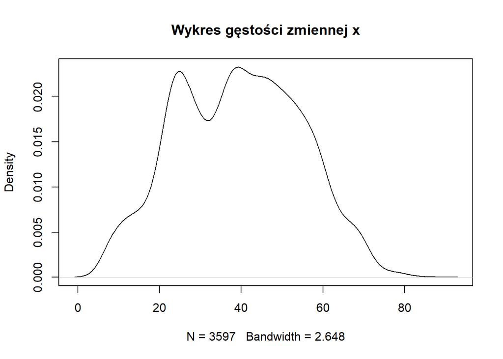

```r
plot(density(dane_A1$Age), main = "Wykres gęstości zmiennej x")
```

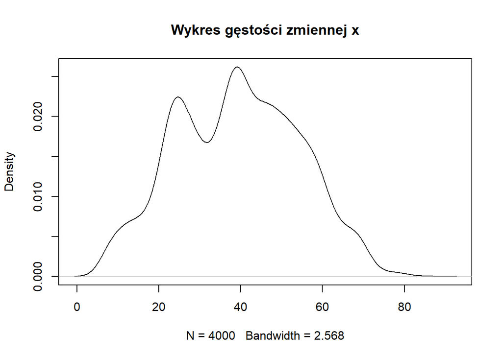

```r
plot(density(dane_AII$Age), main = "Wykres gęstości zmiennej x")
```

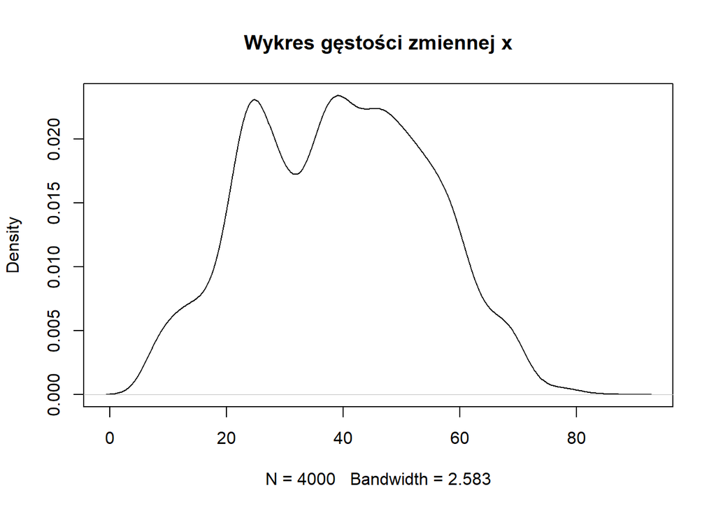

```r
plot(density(imputed_A$Age), main = "Wykres gęstości zmiennej x")
```

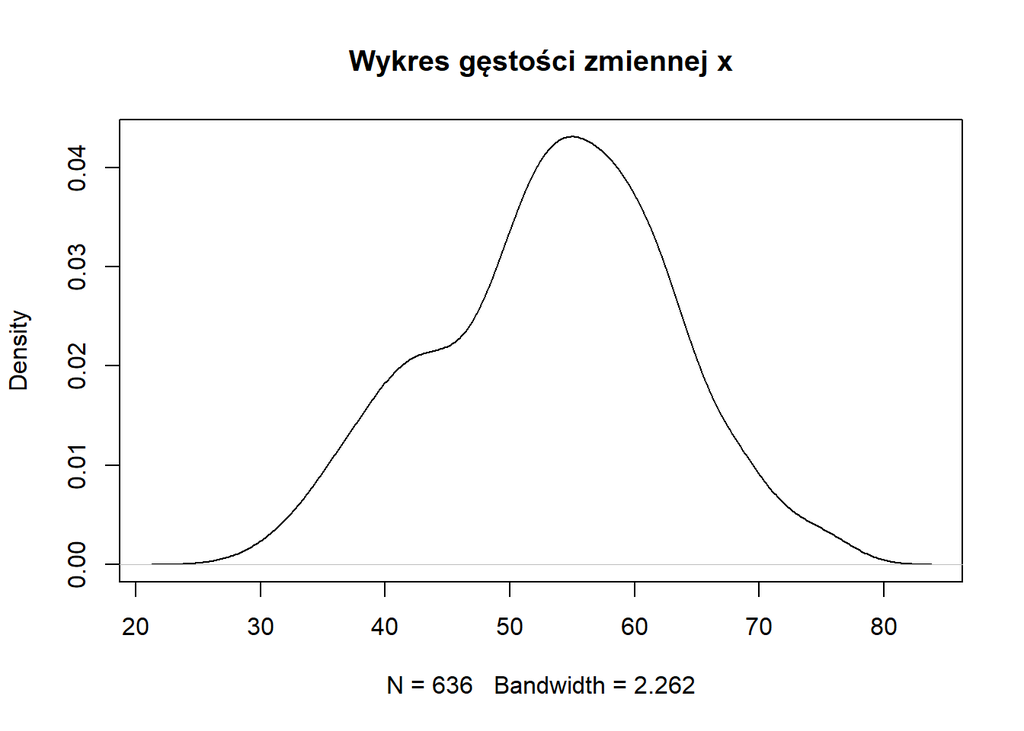

```r
plot(density(dane_H1$Age), main = "Wykres gęstości zmiennej x")
```

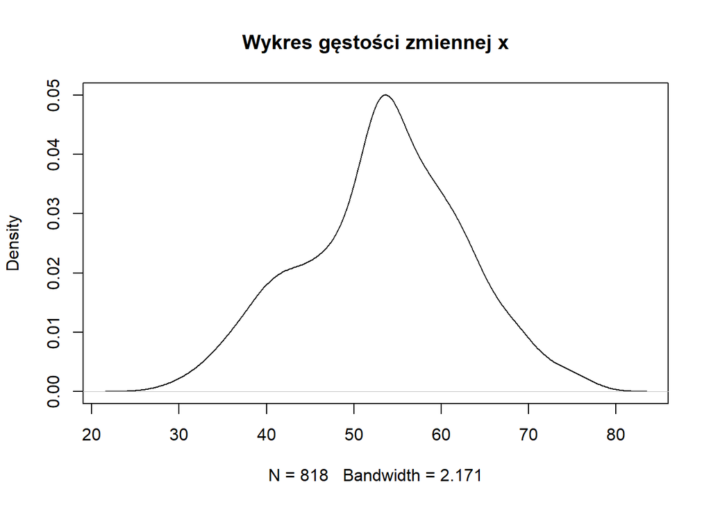

```r
plot(density(dane_HII$Age), main = "Wykres gęstości zmiennej x")
```

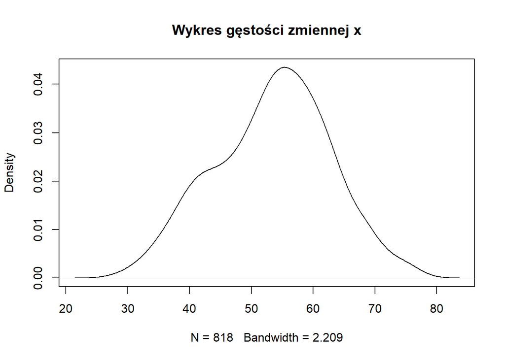

```r
plot(density(imputed_H$Age), main = "Wykres gęstości zmiennej x")
```

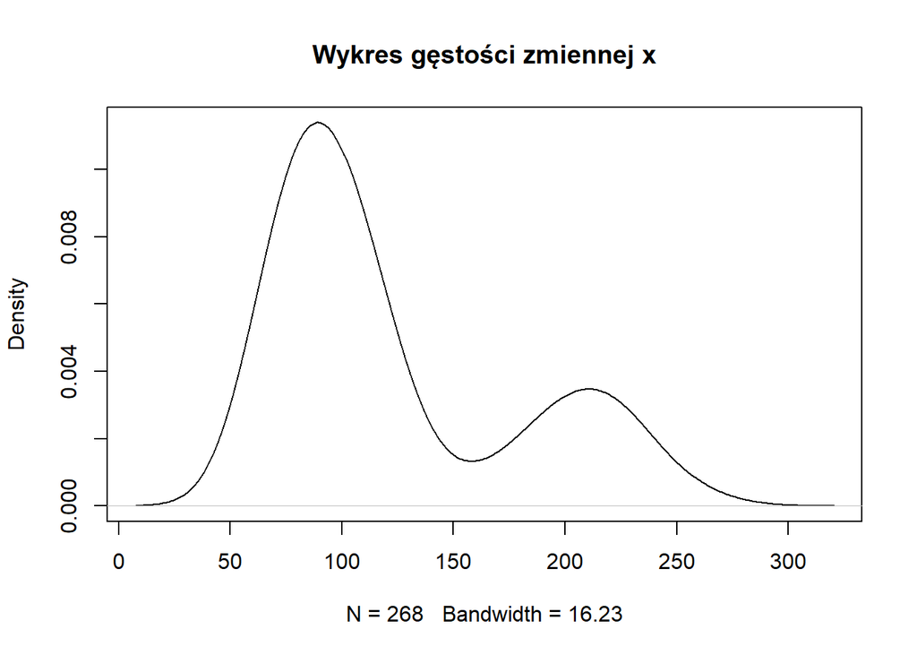

```r
plot(density(dane_S1$avg_glucose_level), main = "Wykres gęstości zmiennej x")
```

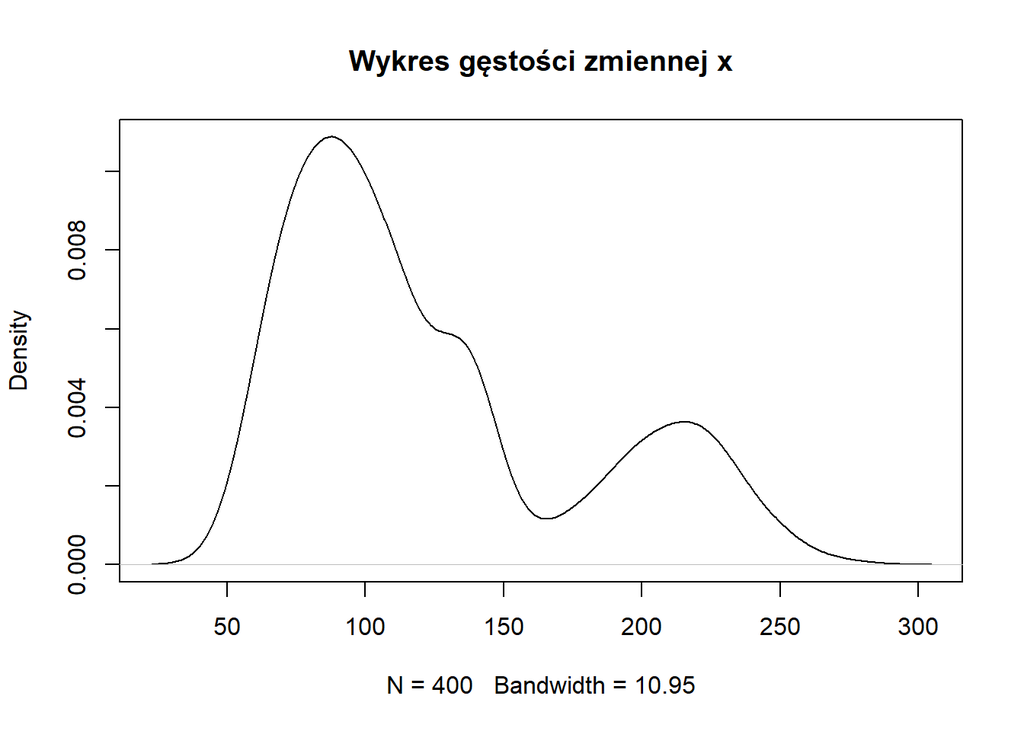

```r
plot(density(dane_SII$avg_glucose_level), main = "Wykres gęstości zmiennej x")
```

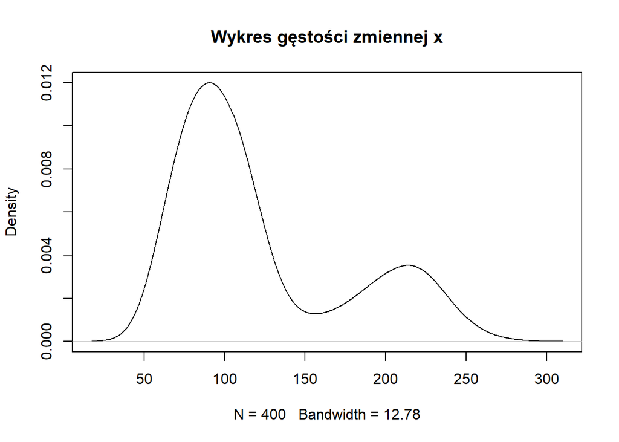

```r
plot(density(imputed_S$avg_glucose_level), main = "Wykres gęstości zmiennej x")
```

We wszystkich przypadkach można uznać, że otrzymane rozkłady są podbne, można jedynie odtnotawać, że wykresy dla drugiej metody różnią się najbardziej.

## **Czy sposób eliminacji braków danych wpływa na uzyskiwane wyniki?**

Porównując wyniki dla różnych zestawów danych i metod uzupełniania braków, można wywnioskować, że wybór optymalnej metody uzupełniania braków zależy od konkretnego zestawu danych. Oto wnioski z analizy wyników:

**Zestaw Stroke:**

Najlepsza dokładność została osiągnięta przy użyciu pierwszej metody (usunięcie braków danych) i wyniosła 0,7973. Dla drugiej metody (zastąpienie średnią/medianą) oraz trzeciej metody (prognozowanie braków) dokładność wyniosła tyle samo, 0,7565. Wybór metody zależy od konkretnego zestawu danych, ale usunięcie braków danych daje lepsze wyniki w tym przypadku.

**Zestaw Heart:**

Dokładność dla pierwszej metody wyniosła 0,8403, a dla pozostałych metod 0,8332. W tym przypadku pierwsza metoda wydaje się być najlepsza. Podsumowując, wybór optymalnej metody uzupełniania braków zależy od charakterystyki zestawu danych i celu analizy. Warto dostosować metodę do konkretnych danych i zwracać uwagę na kluczowe miary, takie jak dokładność i czułość, które są istotne w kontekście analizy i celów badawczych.